# Risk Factor Analysis

## Outcome Variable

**Outcome Variable:** whz

## Predictor Variables

**Intervention Variable:** mwtkg

**Adjustment Set:**

unadjusted

## Stratifying Variables

The analysis was stratified on these variable(s):

- agecat
- studyid
- country

## Data Summary

| agecat | studyid | country | mwtkg | n_cell | n |
| --- | --- | --- | --- | --- | --- |
| Birth | ki0047075b-MAL-ED | BANGLADESH | >=58 kg | 46 | 233 |
| Birth | ki0047075b-MAL-ED | BANGLADESH | <52 kg | 144 | 233 |
| Birth | ki0047075b-MAL-ED | BANGLADESH | [52-58) kg | 43 | 233 |
| Birth | ki0047075b-MAL-ED | BRAZIL | >=58 kg | 117 | 176 |
| Birth | ki0047075b-MAL-ED | BRAZIL | <52 kg | 31 | 176 |
| Birth | ki0047075b-MAL-ED | BRAZIL | [52-58) kg | 28 | 176 |
| Birth | ki0047075b-MAL-ED | INDIA | >=58 kg | 36 | 195 |
| Birth | ki0047075b-MAL-ED | INDIA | <52 kg | 121 | 195 |
| Birth | ki0047075b-MAL-ED | INDIA | [52-58) kg | 38 | 195 |
| Birth | ki0047075b-MAL-ED | NEPAL | >=58 kg | 56 | 167 |
| Birth | ki0047075b-MAL-ED | NEPAL | <52 kg | 48 | 167 |
| Birth | ki0047075b-MAL-ED | NEPAL | [52-58) kg | 63 | 167 |
| Birth | ki0047075b-MAL-ED | PERU | >=58 kg | 97 | 269 |
| Birth | ki0047075b-MAL-ED | PERU | <52 kg | 104 | 269 |
| Birth | ki0047075b-MAL-ED | PERU | [52-58) kg | 68 | 269 |
| Birth | ki0047075b-MAL-ED | SOUTH AFRICA | >=58 kg | 165 | 226 |
| Birth | ki0047075b-MAL-ED | SOUTH AFRICA | <52 kg | 23 | 226 |
| Birth | ki0047075b-MAL-ED | SOUTH AFRICA | [52-58) kg | 38 | 226 |
| Birth | ki0047075b-MAL-ED | TANZANIA, UNITED REPUBLIC OF | >=58 kg | 51 | 116 |
| Birth | ki0047075b-MAL-ED | TANZANIA, UNITED REPUBLIC OF | <52 kg | 37 | 116 |
| Birth | ki0047075b-MAL-ED | TANZANIA, UNITED REPUBLIC OF | [52-58) kg | 28 | 116 |
| Birth | ki1000304b-SAS-CompFeed | INDIA | >=58 kg | 12 | 162 |
| Birth | ki1000304b-SAS-CompFeed | INDIA | <52 kg | 124 | 162 |
| Birth | ki1000304b-SAS-CompFeed | INDIA | [52-58) kg | 26 | 162 |
| Birth | ki1017093-NIH-Birth | BANGLADESH | >=58 kg | 2 | 28 |
| Birth | ki1017093-NIH-Birth | BANGLADESH | <52 kg | 23 | 28 |
| Birth | ki1017093-NIH-Birth | BANGLADESH | [52-58) kg | 3 | 28 |
| Birth | ki1017093c-NIH-Crypto | BANGLADESH | >=58 kg | 4 | 23 |
| Birth | ki1017093c-NIH-Crypto | BANGLADESH | <52 kg | 17 | 23 |
| Birth | ki1017093c-NIH-Crypto | BANGLADESH | [52-58) kg | 2 | 23 |

[output cut: 93 more lines]

The following strata were considered:

- agecat: 24 months, studyid: ki0047075b-MAL-ED, country: BANGLADESH
- agecat: 24 months, studyid: ki0047075b-MAL-ED, country: BRAZIL
- agecat: 24 months, studyid: ki0047075b-MAL-ED, country: INDIA
- agecat: 24 months, studyid: ki0047075b-MAL-ED, country: NEPAL
- agecat: 24 months, studyid: ki0047075b-MAL-ED, country: PERU
- agecat: 24 months, studyid: ki0047075b-MAL-ED, country: SOUTH AFRICA
- agecat: 24 months, studyid: ki0047075b-MAL-ED, country: TANZANIA, UNITED REPUBLIC OF
- agecat: 24 months, studyid: ki1017093-NIH-Birth, country: BANGLADESH
- agecat: 24 months, studyid: ki1017093b-PROVIDE, country: BANGLADESH
- agecat: 24 months, studyid: ki1017093c-NIH-Crypto, country: BANGLADESH
- agecat: 24 months, studyid: ki1066203-TanzaniaChild2, country: TANZANIA, UNITED REPUBLIC OF
- agecat: 24 months, studyid: ki1119695-PROBIT, country: BELARUS
- agecat: 24 months, studyid: ki1126311-ZVITAMBO, country: ZIMBABWE
- agecat: 24 months, studyid: ki1148112-LCNI-5, country: MALAWI
- agecat: 6 months, studyid: ki0047075b-MAL-ED, country: BANGLADESH
- agecat: 6 months, studyid: ki0047075b-MAL-ED, country: BRAZIL
- agecat: 6 months, studyid: ki0047075b-MAL-ED, country: INDIA
- agecat: 6 months, studyid: ki0047075b-MAL-ED, country: NEPAL
- agecat: 6 months, studyid: ki0047075b-MAL-ED, country: PERU
- agecat: 6 months, studyid: ki0047075b-MAL-ED, country: SOUTH AFRICA
- agecat: 6 months, studyid: ki0047075b-MAL-ED, country: TANZANIA, UNITED REPUBLIC OF
- agecat: 6 months, studyid: ki1000304b-SAS-CompFeed, country: INDIA
- agecat: 6 months, studyid: ki1017093-NIH-Birth, country: BANGLADESH
- agecat: 6 months, studyid: ki1017093b-PROVIDE, country: BANGLADESH
- agecat: 6 months, studyid: ki1017093c-NIH-Crypto, country: BANGLADESH
- agecat: 6 months, studyid: ki1066203-TanzaniaChild2, country: TANZANIA, UNITED REPUBLIC OF
- agecat: 6 months, studyid: ki1119695-PROBIT, country: BELARUS
- agecat: 6 months, studyid: ki1126311-ZVITAMBO, country: ZIMBABWE
- agecat: 6 months, studyid: ki1148112-LCNI-5, country: MALAWI
- agecat: Birth, studyid: ki0047075b-MAL-ED, country: BANGLADESH
- agecat: Birth, studyid: ki0047075b-MAL-ED, country: BRAZIL
- agecat: Birth, studyid: ki0047075b-MAL-ED, country: INDIA
- agecat: Birth, studyid: ki0047075b-MAL-ED, country: NEPAL
- agecat: Birth, studyid: ki0047075b-MAL-ED, country: PERU
- agecat: Birth, studyid: ki0047075b-MAL-ED, country: SOUTH AFRICA
- agecat: Birth, studyid: ki0047075b-MAL-ED, country: TANZANIA, UNITED REPUBLIC OF
- agecat: Birth, studyid: ki1000304b-SAS-CompFeed, country: INDIA
- agecat: Birth, studyid: ki1017093-NIH-Birth, country: BANGLADESH
- agecat: Birth, studyid: ki1017093c-NIH-Crypto, country: BANGLADESH
- agecat: Birth, studyid: ki1119695-PROBIT, country: BELARUS
- agecat: Birth, studyid: ki1126311-ZVITAMBO, country: ZIMBABWE

### Dropped Strata

Some strata were dropped due to rare outcomes:

- agecat: Birth, studyid: ki1017093-NIH-Birth, country: BANGLADESH
- agecat: Birth, studyid: ki1017093c-NIH-Crypto, country: BANGLADESH
- agecat: 24 months, studyid: ki1066203-TanzaniaChild2, country: TANZANIA, UNITED REPUBLIC OF

## Methods Detail

We’re interested in the causal parameters $E[Y_a]$ for all values of $a \in \mathcal{A}$. These parameters represent the mean outcome if, possibly contrary to fact, we intervened to set all units to have $A=a$. Under the randomization and positivity assumptions, these are identified by the statistical parameters $\psi_a=E_W[E_{Y|A,W}(Y|A=a,W)]$. In addition, we’re interested in the mean of $Y$, $E[Y]$ under no intervention (the observed mean). We will estimate these parameters by using SuperLearner to fit the relevant likelihood factors – $E_{Y|A,W}(Y|A=a,W)$ and $p(A=a|W)$, and then updating our likelihood fit using a joint TMLE.

For unadjusted analyses ($W=\{\}$), initial likelihoods were estimated using Lrnr_glm to estimate the simple $E(Y|A)$ and Lrnr_mean to estimate $p(A)$. For adjusted analyses, a small library containing Lrnr_glmnet, Lrnr_xgboost, and Lrnr_mean was used.

Having estimated these parameters, we will then use the delta method to estimate relative risks and attributable risks relative to a prespecified baseline level of $A$.

# Results Detail

## Results Plots

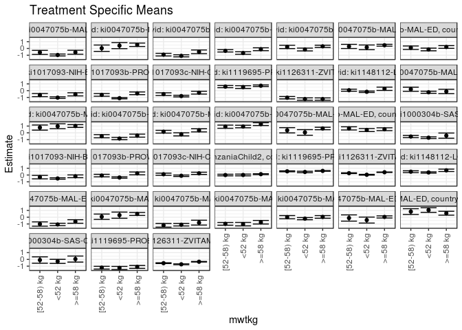

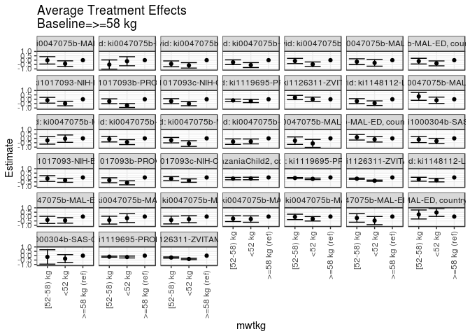

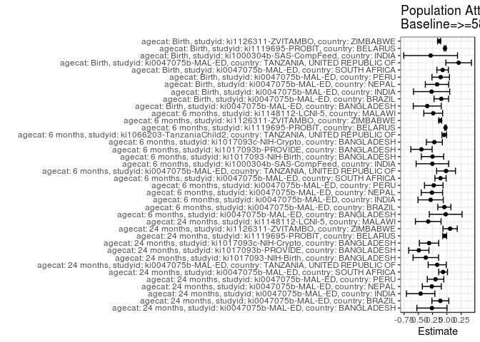

## Results Table

### Parameter: TSM

| agecat | studyid | country | intervention_level | baseline_level | estimate | ci_lower | ci_upper |
| --- | --- | --- | --- | --- | --- | --- | --- |
| Birth | ki0047075b-MAL-ED | BANGLADESH | >=58 kg | NA | -0.6297826 | -0.8909645 | -0.3686007 |
| Birth | ki0047075b-MAL-ED | BANGLADESH | <52 kg | NA | -1.0707639 | -1.2489224 | -0.8926054 |
| Birth | ki0047075b-MAL-ED | BANGLADESH | [52-58) kg | NA | -1.0097674 | -1.3260114 | -0.6935234 |
| Birth | ki0047075b-MAL-ED | BRAZIL | >=58 kg | NA | 0.4796581 | 0.2613249 | 0.6979913 |
| Birth | ki0047075b-MAL-ED | BRAZIL | <52 kg | NA | 0.3016129 | -0.1553497 | 0.7585755 |
| Birth | ki0047075b-MAL-ED | BRAZIL | [52-58) kg | NA | 0.0707143 | -0.3225785 | 0.4640071 |
| Birth | ki0047075b-MAL-ED | INDIA | >=58 kg | NA | -0.8033333 | -1.1605636 | -0.4461031 |
| Birth | ki0047075b-MAL-ED | INDIA | <52 kg | NA | -1.1092562 | -1.2902879 | -0.9282245 |
| Birth | ki0047075b-MAL-ED | INDIA | [52-58) kg | NA | -1.1971053 | -1.4669908 | -0.9272198 |
| Birth | ki0047075b-MAL-ED | NEPAL | >=58 kg | NA | -0.7414286 | -1.0031468 | -0.4797103 |
| Birth | ki0047075b-MAL-ED | NEPAL | <52 kg | NA | -1.0250000 | -1.2802996 | -0.7697004 |
| Birth | ki0047075b-MAL-ED | NEPAL | [52-58) kg | NA | -0.9793651 | -1.1845618 | -0.7741683 |
| Birth | ki0047075b-MAL-ED | PERU | >=58 kg | NA | 0.0416495 | -0.1555215 | 0.2388205 |
| Birth | ki0047075b-MAL-ED | PERU | <52 kg | NA | -0.2129808 | -0.3742073 | -0.0517542 |
| Birth | ki0047075b-MAL-ED | PERU | [52-58) kg | NA | 0.0048529 | -0.2323192 | 0.2420251 |
| Birth | ki0047075b-MAL-ED | SOUTH AFRICA | >=58 kg | NA | 0.0389091 | -0.1215469 | 0.1993650 |
| Birth | ki0047075b-MAL-ED | SOUTH AFRICA | <52 kg | NA | -0.4226087 | -0.8633104 | 0.0180930 |
| Birth | ki0047075b-MAL-ED | SOUTH AFRICA | [52-58) kg | NA | -0.1189474 | -0.5789308 | 0.3410361 |
| Birth | ki0047075b-MAL-ED | TANZANIA, UNITED REPUBLIC OF | >=58 kg | NA | 0.5888235 | 0.3003594 | 0.8772877 |
| Birth | ki0047075b-MAL-ED | TANZANIA, UNITED REPUBLIC OF | <52 kg | NA | 1.0545946 | 0.7106469 | 1.3985422 |
| Birth | ki0047075b-MAL-ED | TANZANIA, UNITED REPUBLIC OF | [52-58) kg | NA | 0.8275000 | 0.4002654 | 1.2547346 |
| Birth | ki1000304b-SAS-CompFeed | INDIA | >=58 kg | NA | 0.0483333 | -0.3979297 | 0.4945964 |
| Birth | ki1000304b-SAS-CompFeed | INDIA | <52 kg | NA | -0.2920968 | -0.5938869 | 0.0096934 |
| Birth | ki1000304b-SAS-CompFeed | INDIA | [52-58) kg | NA | -0.0953846 | -0.5661531 | 0.3753839 |
| Birth | ki1119695-PROBIT | BELARUS | >=58 kg | NA | -1.1117229 | -1.3258636 | -0.8975821 |
| Birth | ki1119695-PROBIT | BELARUS | <52 kg | NA | -1.2655694 | -1.4936246 | -1.0375142 |
| Birth | ki1119695-PROBIT | BELARUS | [52-58) kg | NA | -1.2274681 | -1.4325809 | -1.0223553 |
| Birth | ki1126311-ZVITAMBO | ZIMBABWE | >=58 kg | NA | -0.3468139 | -0.3870259 | -0.3066019 |
| Birth | ki1126311-ZVITAMBO | ZIMBABWE | <52 kg | NA | -0.7267134 | -0.7881367 | -0.6652900 |
| Birth | ki1126311-ZVITAMBO | ZIMBABWE | [52-58) kg | NA | -0.5612649 | -0.6164255 | -0.5061042 |

[output cut: 84 more lines]

### Parameter: E(Y)

| agecat | studyid | country | intervention_level | baseline_level | estimate | ci_lower | ci_upper |
| --- | --- | --- | --- | --- | --- | --- | --- |
| Birth | ki0047075b-MAL-ED | BANGLADESH | NA | NA | -0.9724464 | -1.1091046 | -0.8357881 |
| Birth | ki0047075b-MAL-ED | BRAZIL | NA | NA | 0.3832386 | 0.2044597 | 0.5620175 |
| Birth | ki0047075b-MAL-ED | INDIA | NA | NA | -1.0698974 | -1.2115847 | -0.9282102 |
| Birth | ki0047075b-MAL-ED | NEPAL | NA | NA | -0.9126946 | -1.0520834 | -0.7733058 |
| Birth | ki0047075b-MAL-ED | PERU | NA | NA | -0.0660967 | -0.1789362 | 0.0467429 |
| Birth | ki0047075b-MAL-ED | SOUTH AFRICA | NA | NA | -0.0346018 | -0.1831486 | 0.1139451 |
| Birth | ki0047075b-MAL-ED | TANZANIA, UNITED REPUBLIC OF | NA | NA | 0.7950000 | 0.5947353 | 0.9952647 |
| Birth | ki1000304b-SAS-CompFeed | INDIA | NA | NA | -0.2353086 | -0.4984656 | 0.0278483 |
| Birth | ki1119695-PROBIT | BELARUS | NA | NA | -1.1441825 | -1.3547365 | -0.9336286 |
| Birth | ki1126311-ZVITAMBO | ZIMBABWE | NA | NA | -0.4819806 | -0.5108811 | -0.4530800 |
| 6 months | ki0047075b-MAL-ED | BANGLADESH | NA | NA | -0.1397960 | -0.2688682 | -0.0107238 |
| 6 months | ki0047075b-MAL-ED | BRAZIL | NA | NA | 0.9644952 | 0.7999744 | 1.1290160 |
| 6 months | ki0047075b-MAL-ED | INDIA | NA | NA | -0.6987943 | -0.8241325 | -0.5734561 |
| 6 months | ki0047075b-MAL-ED | NEPAL | NA | NA | 0.1110452 | -0.0202712 | 0.2423616 |
| 6 months | ki0047075b-MAL-ED | PERU | NA | NA | 1.0563787 | 0.9342938 | 1.1784635 |
| 6 months | ki0047075b-MAL-ED | SOUTH AFRICA | NA | NA | 0.5290428 | 0.3750394 | 0.6830463 |
| 6 months | ki0047075b-MAL-ED | TANZANIA, UNITED REPUBLIC OF | NA | NA | 0.5170513 | 0.3872178 | 0.6468847 |
| 6 months | ki1000304b-SAS-CompFeed | INDIA | NA | NA | -0.6674586 | -0.8042294 | -0.5306877 |
| 6 months | ki1017093-NIH-Birth | BANGLADESH | NA | NA | -0.4389101 | -0.5279432 | -0.3498771 |
| 6 months | ki1017093b-PROVIDE | BANGLADESH | NA | NA | -0.2079891 | -0.2925599 | -0.1234183 |
| 6 months | ki1017093c-NIH-Crypto | BANGLADESH | NA | NA | 0.0297622 | -0.0491685 | 0.1086930 |
| 6 months | ki1066203-TanzaniaChild2 | TANZANIA, UNITED REPUBLIC OF | NA | NA | 0.0780261 | 0.0247830 | 0.1312691 |
| 6 months | ki1119695-PROBIT | BELARUS | NA | NA | 0.5834072 | 0.5254491 | 0.6413653 |
| 6 months | ki1126311-ZVITAMBO | ZIMBABWE | NA | NA | 0.2953392 | 0.2687669 | 0.3219114 |
| 6 months | ki1148112-LCNI-5 | MALAWI | NA | NA | 0.4518399 | 0.3806212 | 0.5230586 |
| 24 months | ki0047075b-MAL-ED | BANGLADESH | NA | NA | -0.8208255 | -0.9429246 | -0.6987264 |
| 24 months | ki0047075b-MAL-ED | BRAZIL | NA | NA | 0.4282738 | 0.2252365 | 0.6313111 |
| 24 months | ki0047075b-MAL-ED | INDIA | NA | NA | -0.9525664 | -1.0684455 | -0.8366872 |
| 24 months | ki0047075b-MAL-ED | NEPAL | NA | NA | -0.3764474 | -0.4898516 | -0.2630431 |
| 24 months | ki0047075b-MAL-ED | PERU | NA | NA | 0.1199005 | -0.0000331 | 0.2398341 |
| 24 months | ki0047075b-MAL-ED | SOUTH AFRICA | NA | NA | 0.4096154 | 0.2902946 | 0.5289362 |
| 24 months | ki0047075b-MAL-ED | TANZANIA, UNITED REPUBLIC OF | NA | NA | 0.0500935 | -0.0748234 | 0.1750103 |
| 24 months | ki1017093-NIH-Birth | BANGLADESH | NA | NA | -0.9115790 | -1.0095022 | -0.8136559 |
| 24 months | ki1017093b-PROVIDE | BANGLADESH | NA | NA | -0.8864991 | -0.9695215 | -0.8034768 |
| 24 months | ki1017093c-NIH-Crypto | BANGLADESH | NA | NA | -0.6103502 | -0.7050157 | -0.5156847 |
| 24 months | ki1119695-PROBIT | BELARUS | NA | NA | 0.6877387 | 0.5737746 | 0.8017027 |
| 24 months | ki1126311-ZVITAMBO | ZIMBABWE | NA | NA | -1.1865133 | -1.2873598 | -1.0856668 |
| 24 months | ki1148112-LCNI-5 | MALAWI | NA | NA | -0.0467082 | -0.1287046 | 0.0352882 |

### Parameter: ATE

| agecat | studyid | country | intervention_level | baseline_level | estimate | ci_lower | ci_upper |
| --- | --- | --- | --- | --- | --- | --- | --- |
| Birth | ki0047075b-MAL-ED | BANGLADESH | >=58 kg | >=58 kg | 0.0000000 | 0.0000000 | 0.0000000 |
| Birth | ki0047075b-MAL-ED | BANGLADESH | <52 kg | >=58 kg | -0.4409813 | -0.7571401 | -0.1248224 |
| Birth | ki0047075b-MAL-ED | BANGLADESH | [52-58) kg | >=58 kg | -0.3799848 | -0.7901387 | 0.0301691 |
| Birth | ki0047075b-MAL-ED | BRAZIL | >=58 kg | >=58 kg | 0.0000000 | 0.0000000 | 0.0000000 |
| Birth | ki0047075b-MAL-ED | BRAZIL | <52 kg | >=58 kg | -0.1780452 | -0.6844879 | 0.3283974 |
| Birth | ki0047075b-MAL-ED | BRAZIL | [52-58) kg | >=58 kg | -0.4089438 | -0.8587756 | 0.0408879 |
| Birth | ki0047075b-MAL-ED | INDIA | >=58 kg | >=58 kg | 0.0000000 | 0.0000000 | 0.0000000 |
| Birth | ki0047075b-MAL-ED | INDIA | <52 kg | >=58 kg | -0.3059229 | -0.7064050 | 0.0945593 |
| Birth | ki0047075b-MAL-ED | INDIA | [52-58) kg | >=58 kg | -0.3937719 | -0.8414902 | 0.0539463 |
| Birth | ki0047075b-MAL-ED | NEPAL | >=58 kg | >=58 kg | 0.0000000 | 0.0000000 | 0.0000000 |
| Birth | ki0047075b-MAL-ED | NEPAL | <52 kg | >=58 kg | -0.2835714 | -0.6491864 | 0.0820436 |
| Birth | ki0047075b-MAL-ED | NEPAL | [52-58) kg | >=58 kg | -0.2379365 | -0.5705055 | 0.0946325 |
| Birth | ki0047075b-MAL-ED | PERU | >=58 kg | >=58 kg | 0.0000000 | 0.0000000 | 0.0000000 |
| Birth | ki0047075b-MAL-ED | PERU | <52 kg | >=58 kg | -0.2546303 | -0.5093269 | 0.0000664 |
| Birth | ki0047075b-MAL-ED | PERU | [52-58) kg | >=58 kg | -0.0367965 | -0.3452232 | 0.2716301 |
| Birth | ki0047075b-MAL-ED | SOUTH AFRICA | >=58 kg | >=58 kg | 0.0000000 | 0.0000000 | 0.0000000 |
| Birth | ki0047075b-MAL-ED | SOUTH AFRICA | <52 kg | >=58 kg | -0.4615178 | -0.9305211 | 0.0074855 |
| Birth | ki0047075b-MAL-ED | SOUTH AFRICA | [52-58) kg | >=58 kg | -0.1578565 | -0.6450226 | 0.3293097 |
| Birth | ki0047075b-MAL-ED | TANZANIA, UNITED REPUBLIC OF | >=58 kg | >=58 kg | 0.0000000 | 0.0000000 | 0.0000000 |
| Birth | ki0047075b-MAL-ED | TANZANIA, UNITED REPUBLIC OF | <52 kg | >=58 kg | 0.4657711 | 0.0168707 | 0.9146714 |
| Birth | ki0047075b-MAL-ED | TANZANIA, UNITED REPUBLIC OF | [52-58) kg | >=58 kg | 0.2386765 | -0.2768242 | 0.7541772 |
| Birth | ki1000304b-SAS-CompFeed | INDIA | >=58 kg | >=58 kg | 0.0000000 | 0.0000000 | 0.0000000 |
| Birth | ki1000304b-SAS-CompFeed | INDIA | <52 kg | >=58 kg | -0.3404301 | -0.8005196 | 0.1196594 |
| Birth | ki1000304b-SAS-CompFeed | INDIA | [52-58) kg | >=58 kg | -0.1437179 | -0.9680700 | 0.6806341 |
| Birth | ki1119695-PROBIT | BELARUS | >=58 kg | >=58 kg | 0.0000000 | 0.0000000 | 0.0000000 |
| Birth | ki1119695-PROBIT | BELARUS | <52 kg | >=58 kg | -0.1538465 | -0.2597279 | -0.0479651 |
| Birth | ki1119695-PROBIT | BELARUS | [52-58) kg | >=58 kg | -0.1157452 | -0.1736132 | -0.0578773 |
| Birth | ki1126311-ZVITAMBO | ZIMBABWE | >=58 kg | >=58 kg | 0.0000000 | 0.0000000 | 0.0000000 |
| Birth | ki1126311-ZVITAMBO | ZIMBABWE | <52 kg | >=58 kg | -0.3798994 | -0.4533149 | -0.3064840 |
| Birth | ki1126311-ZVITAMBO | ZIMBABWE | [52-58) kg | >=58 kg | -0.2144509 | -0.2827130 | -0.1461889 |

[output cut: 84 more lines]

### Parameter: PAR

| agecat | studyid | country | intervention_level | baseline_level | estimate | ci_lower | ci_upper |
| --- | --- | --- | --- | --- | --- | --- | --- |
| Birth | ki0047075b-MAL-ED | BANGLADESH | >=58 kg | NA | -0.3426637 | -0.5875237 | -0.0978038 |
| Birth | ki0047075b-MAL-ED | BRAZIL | >=58 kg | NA | -0.0964195 | -0.2239054 | 0.0310665 |
| Birth | ki0047075b-MAL-ED | INDIA | >=58 kg | NA | -0.2665641 | -0.5836917 | 0.0505635 |
| Birth | ki0047075b-MAL-ED | NEPAL | >=58 kg | NA | -0.1712660 | -0.3761757 | 0.0336436 |
| Birth | ki0047075b-MAL-ED | PERU | >=58 kg | NA | -0.1077461 | -0.2612776 | 0.0457853 |
| Birth | ki0047075b-MAL-ED | SOUTH AFRICA | >=58 kg | NA | -0.0735109 | -0.1745970 | 0.0275753 |
| Birth | ki0047075b-MAL-ED | TANZANIA, UNITED REPUBLIC OF | >=58 kg | NA | 0.2061765 | -0.0177626 | 0.4301156 |
| Birth | ki1000304b-SAS-CompFeed | INDIA | >=58 kg | NA | -0.2836420 | -0.7542670 | 0.1869830 |
| Birth | ki1119695-PROBIT | BELARUS | >=58 kg | NA | -0.0324597 | -0.0481492 | -0.0167702 |
| Birth | ki1126311-ZVITAMBO | ZIMBABWE | >=58 kg | NA | -0.1351666 | -0.1623140 | -0.1080193 |
| 6 months | ki0047075b-MAL-ED | BANGLADESH | >=58 kg | NA | -0.0201583 | -0.3071045 | 0.2667879 |
| 6 months | ki0047075b-MAL-ED | BRAZIL | >=58 kg | NA | -0.0436070 | -0.1585686 | 0.0713546 |
| 6 months | ki0047075b-MAL-ED | INDIA | >=58 kg | NA | -0.2838777 | -0.5052985 | -0.0624568 |
| 6 months | ki0047075b-MAL-ED | NEPAL | >=58 kg | NA | -0.2612122 | -0.4479965 | -0.0744279 |
| 6 months | ki0047075b-MAL-ED | PERU | >=58 kg | NA | -0.2287880 | -0.3914677 | -0.0661083 |
| 6 months | ki0047075b-MAL-ED | SOUTH AFRICA | >=58 kg | NA | -0.1109572 | -0.2088382 | -0.0130761 |
| 6 months | ki0047075b-MAL-ED | TANZANIA, UNITED REPUBLIC OF | >=58 kg | NA | -0.0140125 | -0.1795152 | 0.1514901 |
| 6 months | ki1000304b-SAS-CompFeed | INDIA | >=58 kg | NA | -0.2529131 | -0.5380050 | 0.0321788 |
| 6 months | ki1017093-NIH-Birth | BANGLADESH | >=58 kg | NA | -0.2507529 | -0.4467461 | -0.0547596 |
| 6 months | ki1017093b-PROVIDE | BANGLADESH | >=58 kg | NA | -0.4443099 | -0.6307868 | -0.2578329 |
| 6 months | ki1017093c-NIH-Crypto | BANGLADESH | >=58 kg | NA | -0.2184986 | -0.3575761 | -0.0794211 |
| 6 months | ki1066203-TanzaniaChild2 | TANZANIA, UNITED REPUBLIC OF | >=58 kg | NA | -0.0456432 | -0.0863195 | -0.0049670 |
| 6 months | ki1119695-PROBIT | BELARUS | >=58 kg | NA | -0.0235754 | -0.0351992 | -0.0119515 |
| 6 months | ki1126311-ZVITAMBO | ZIMBABWE | >=58 kg | NA | -0.1159072 | -0.1412293 | -0.0905852 |
| 6 months | ki1148112-LCNI-5 | MALAWI | >=58 kg | NA | -0.2383355 | -0.4033017 | -0.0733694 |
| 24 months | ki0047075b-MAL-ED | BANGLADESH | >=58 kg | NA | -0.2609505 | -0.5248414 | 0.0029405 |
| 24 months | ki0047075b-MAL-ED | BRAZIL | >=58 kg | NA | -0.1136528 | -0.2620040 | 0.0346985 |
| 24 months | ki0047075b-MAL-ED | INDIA | >=58 kg | NA | -0.4584874 | -0.7072645 | -0.2097104 |
| 24 months | ki0047075b-MAL-ED | NEPAL | >=58 kg | NA | -0.2632895 | -0.4297973 | -0.0967816 |
| 24 months | ki0047075b-MAL-ED | PERU | >=58 kg | NA | -0.1975021 | -0.3418278 | -0.0531764 |
| 24 months | ki0047075b-MAL-ED | SOUTH AFRICA | >=58 kg | NA | -0.0657418 | -0.1428423 | 0.0113588 |
| 24 months | ki0047075b-MAL-ED | TANZANIA, UNITED REPUBLIC OF | >=58 kg | NA | -0.1684431 | -0.3264861 | -0.0104002 |
| 24 months | ki1017093-NIH-Birth | BANGLADESH | >=58 kg | NA | -0.3687219 | -0.5924913 | -0.1449526 |
| 24 months | ki1017093b-PROVIDE | BANGLADESH | >=58 kg | NA | -0.4906956 | -0.6679851 | -0.3134060 |
| 24 months | ki1017093c-NIH-Crypto | BANGLADESH | >=58 kg | NA | -0.3112922 | -0.4800473 | -0.1425372 |
| 24 months | ki1119695-PROBIT | BELARUS | >=58 kg | NA | -0.0379760 | -0.0717969 | -0.0041551 |
| 24 months | ki1126311-ZVITAMBO | ZIMBABWE | >=58 kg | NA | 0.0571394 | -0.0677026 | 0.1819813 |
| 24 months | ki1148112-LCNI-5 | MALAWI | >=58 kg | NA | -0.3257493 | -0.5503714 | -0.1011272 |